# 1_Logistic_Regression_Titanic

First, let's import some Python libraries that will be helpful for data manipulation and visualization. As it turns out, the %matplotlib inline below was necessary for Jupyter Notebook to display plots in the notebook.

```python
%matplotlib inline
import pandas as pd
import matplotlib.pyplot as plt
import numpy as np
import seaborn as sns
from sklearn import linear_model
import re
```

Step 1: Read the data into Jupyter Notebook. Pandas made this REALLY EASY.

```python
pdDataFrame = pd.read_csv('train.csv')
```

The .head method in pandas data frames allows you to look at just the first n rows. You can also examine the .csv file in a spreadsheet program such as Excel.

```python
pdDataFrame.head(5)
```

|  | PassengerId | Survived | Pclass | Name | Sex | Age | SibSp | Parch | Ticket | Fare | Cabin | Embarked |
| --- | --- | --- | --- | --- | --- | --- | --- | --- | --- | --- | --- | --- |
| 0 | 1 | 0 | 3 | Braund, Mr. Owen Harris | male | 22.0 | 1 | 0 | A/5 21171 | 7.2500 | NaN | S |
| 1 | 2 | 1 | 1 | Cumings, Mrs. John Bradley (Florence Briggs Th... | female | 38.0 | 1 | 0 | PC 17599 | 71.2833 | C85 | C |
| 2 | 3 | 1 | 3 | Heikkinen, Miss. Laina | female | 26.0 | 0 | 0 | STON/O2. 3101282 | 7.9250 | NaN | S |
| 3 | 4 | 1 | 1 | Futrelle, Mrs. Jacques Heath (Lily May Peel) | female | 35.0 | 1 | 0 | 113803 | 53.1000 | C123 | S |
| 4 | 5 | 0 | 3 | Allen, Mr. William Henry | male | 35.0 | 0 | 0 | 373450 | 8.0500 | NaN | S |

What kind of data do we have in our data frame? Unlike Python numpy, all ints seem to be 64 bit in Pandas. The object data type refers to strings and other hetergenous data types.

```python
pdDataFrame.dtypes
```

```
PassengerId      int64
Survived         int64
Pclass           int64
Name            object
Sex             object
Age            float64
SibSp            int64
Parch            int64
Ticket          object
Fare           float64
Cabin           object
Embarked        object
dtype: object
```

Some of these predictors seem more useful than others a priori, but we cannot make assumptions about what will be useful in predicting before doing some exploratory statistics. For example, the Embarked category refers to the location at which passengers boarded the Titanic (C: Cherbourg, Q: Queenstown, S:Southampton). Does it seem as if this seemingly unrelated factor has any predictive value for survival?

```python
for EmbkCode in ['S','C','Q']:
    dataSubset_bool = pdDataFrame['Embarked'] == EmbkCode
    dataSubset = pdDataFrame[dataSubset_bool]
    SubsetSurvival = np.sum(dataSubset['Survived'])/dataSubset.shape[0]
    print('Survival for embark Location %s was %s' % (EmbkCode, SubsetSurvival) )
```

```
Survival for embark Location S was 0.33695652173913043
Survival for embark Location C was 0.5535714285714286
Survival for embark Location Q was 0.38961038961038963
```

Interesting! Survival was different depending on the embark location, with those boarding at Southampton being particularly unfotunate. It's likely that embark location is correlated with something else important such as passenger class or number of relatives aboard.

Since I planned on using a logistic regression model as a first pass, I decided to code embark location as dummy variables. This requires the formation of three more data features (one for each location), in which passengers are coded with a 1 if they embarked at that location and 0 otherwise.

Also, since it doesn't really make sense to code passenger class on a linear scale (is 3rd classs 3x 1st?), I also coded three dummy variables for passenger class in anticipation of includison into my model.

```python
#here we code a dummy variable for each location
for EmbkCode in ['S','C','Q']:
    pdDataFrame['e'+EmbkCode] = pdDataFrame['Embarked'] == EmbkCode

#Similarly, we code dummy variables for pclass, since it is categorical, not linear.
for pclass in [1,2,3]:
    pdDataFrame['Class'+str(pclass)] = pdDataFrame['Pclass'] == pclass
```

Similarly, we need to code sex as either 1 or 0.

```python
pdDataFrame["isMale"] = pdDataFrame["Sex"] == "male"
```

Finally, let's check our handiwork and make sure that everything is coded as intended.

```python
pdDataFrame[['eS','eC','eQ','Class1','Class2','Class3','isMale']].head(2)
```

|  | eS | eC | eQ | Class1 | Class2 | Class3 | isMale |
| --- | --- | --- | --- | --- | --- | --- | --- |
| 0 | True | False | False | False | False | True | True |
| 1 | False | True | False | True | False | False | False |

Looks good! At this point, we are ready to explore the data and make a preliminary model. I will ignore cabin number for now, since that information is missing for most of the passengers and it is more difficult to deal with (requiring the dreaded regular expression library).

In addition to the the features that I created dummy variables for, we will use Fare, SibSp (# of siblings/spouses aboard), and Parch (# of parents/children). Note that it is ambiguous who the related passengers are for the last two variables. These features are encoded into a predictor dataframe X, and survival into the dependent frame Y.

```python
Y = pd.DataFrame( pdDataFrame, columns = ["Survived"] )
X = pd.DataFrame(pdDataFrame,columns=['isMale', 'Class1','Class2','Class3' ,
                                      'eS','eQ','eC','Age','Fare','SibSp','Parch'])
```

First, let's look at the fraction of survivng passengers as a function of each feature.

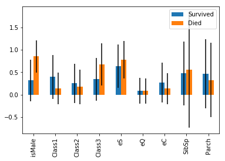

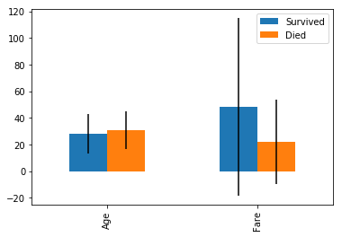

```python
XSurvived = X[Y["Survived"].astype(bool)]
XDied = X[~Y["Survived"].astype(bool)]

#Because Age and Fare are on much different scales than the other categories, we'll plot them separately.
plot1 = ['isMale','Class1','Class2','Class3','eS','eQ','eC','SibSp','Parch']
plot2 = ['Age','Fare']
#make a concatenated structure for plotting
SurvivalBarGraph = pd.concat([XSurvived[plot1].mean(),XDied[plot1].mean()],axis=1)
SurvivalBarGraph_errorbars = pd.concat([XSurvived[plot1].std(), XDied[plot1].std()],axis=1)
#p = dfMean.plot(figsize = (15,5), kind='bar', yerr = dfStd)
ax1 = SurvivalBarGraph.plot(kind = 'bar', yerr = SurvivalBarGraph_errorbars)
ax1.legend(["Survived","Died"])

SBG2 = pd.concat([XSurvived[plot2].mean(),XDied[plot2].mean()],axis=1)
SBG2_eb = pd.concat([XSurvived[plot2].std(), XDied[plot2].std()],axis=1)
ax2 = SBG2.plot(kind = 'bar', yerr = SBG2_eb)
ax2.legend(["Survived","Died"])
```

An initial look at survival by feature shows, in agreement with history, that survival was better for women than men (closer to 0), and for class 1 passengers than class 3 passengers. We should also look for redundant features to help us refine our model in the end. To do this we can use a correlation plot and the lovely seaborn library.

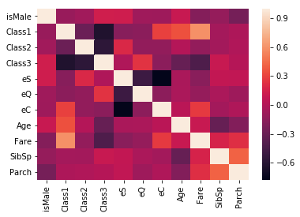

```python
sns.heatmap(X.corr())
```

Values close to 1 indicate high correlation (and -1 anti-correlation), and those close to zero low correlation. From this wee can see that Fare and Class1 are highly correlated, and that SibSp and Parch and highly correlated (and Class 1,2 and 3 are anti-correlated, since they are mutually exclusive. A similar relationship exists for embark location).

There is one last order of business before constructing our first model. We should scale Age and Fare to the same range as the other predictors in our model to improve the performance of the logistic regression. To do this, we'll make a scaled and mean sutracted version of our predictor matrix for those columns.

```python
Xmx = X

for column in ['Age','Fare']:
    Xmx[column] = X[column] - X[column].mean()
    Xmx[column] = Xmx[column]/X[column].std()

Xmx.head(5)
```

|  | isMale | Class1 | Class2 | Class3 | eS | eQ | eC | Age | Fare | SibSp | Parch |
| --- | --- | --- | --- | --- | --- | --- | --- | --- | --- | --- | --- |
| 0 | True | False | False | True | True | False | False | -0.530005 | -0.502163 | 1 | 0 |
| 1 | False | True | False | False | False | False | True | 0.571430 | 0.786404 | 1 | 0 |
| 2 | False | False | False | True | True | False | False | -0.254646 | -0.488580 | 0 | 0 |
| 3 | False | True | False | False | True | False | False | 0.364911 | 0.420494 | 1 | 0 |
| 4 | True | False | False | True | True | False | False | 0.364911 | -0.486064 | 0 | 0 |

Finally we will try our model. One additional problem is missing data in the Age category. Later on, I will impute values to help the model. For now, we will just ignore rows where any data is missing.

```python
#now test logistic model on scaled data
badrows = np.sum( Xmx.isnull().astype('int'),axis=1).astype('bool')
Yg = pd.DataFrame(Y[~badrows])

lmModelSc = linear_model.LogisticRegression()
lmModelSc.fit(Xmx[~badrows],Yg['Survived'])

linPredictSc = lmModelSc.predict(Xmx[~badrows])

Yg['Prediction'] = linPredictSc
Yg['Agreement'] = Yg['Survived'] == Yg['Prediction']

trainingAccuracy = np.sum(Yg['Agreement']) / Yg.shape[0]

#Ygg = pd.concat([Yg,linPredictSc])
#Ygg.head(3)

#trainingAccuracy = np.sum(linPredictSc & Y[~badrows])/np.sum(~badrows)
print ("You got an accuracy of %s on the training data" % trainingAccuracy) #better than before
```

```
You got an accuracy of 0.8053221288515406 on the training data
```

```python
lmModelSc.coef_
```

```
array([[-2.47691368,  1.41740693,  0.3429902 , -0.8060853 ,  0.18833212,
        -0.15027793,  0.57410601, -0.58487618,  0.10003031, -0.33665351,
        -0.04825861]])
```

```python
np.sum(badrows)
```

```
177
```

```python
noAge = np.sum( pdDataFrame["Age"].isnull())
print(noAge)
```

```
177
```

177 of the samples have a NaN where Age should be. Let's add values for these so that we can use the rest of the data to train our logistic regression.

```python
Y.head(3)
```

|  | Survived |
| --- | --- |
| 0 | 0 |
| 1 | 1 |
| 2 | 1 |

```python
Xmx_survived = Xmx[Y["Survived"].astype(bool)].mean()
Xmx_died = Xmx[~Y["Survived"].astype(bool)].mean()
Xmx["Age"][Y["Survived"].astype(bool) & Xmx["Age"].isnull()] = Xmx_survived["Age"]
Xmx["Age"][~Y["Survived"].astype(bool) & Xmx["Age"].isnull()] = Xmx_died["Age"]
```

```python
np.sum(Xmx["Age"].isnull())
```

```
0
```

Replaced NaN values with there means

```python
#lmModelSc = linear_model.LogisticRegression()
lmModelSc.fit(Xmx,Y)

linPredictSc = lmModelSc.predict(Xmx)

YEval = Y.copy()
YEval['Prediction'] = linPredictSc
YEval['Agreement'] = YEval['Survived'] == YEval['Prediction']

trainingAccuracy = np.sum(YEval['Agreement']) / YEval.shape[0]

#Ygg = pd.concat([Yg,linPredictSc])
#Ygg.head(3)

#trainingAccuracy = np.sum(linPredictSc & Y[~badrows])/np.sum(~badrows)
print ("You got an accuracy of %s on the training data" % trainingAccuracy) #better than before
```

```
You got an accuracy of 0.8047138047138047 on the training data
```

```python
#validCabins = pd.notna( pdDataFrame['Cabin'] )
validCabins = ~pdDataFrame['Cabin'].isnull()
hasCabin = pdDataFrame['Cabin'][validCabins]
#cabinSurvival = pd.DataFrame(Y[validCabins],columns=["Survived"])
#cabinSurvival.head(3)

#pdDataFrame.loc[27]
deckSearch = re.compile('([A-Z])([0-9]+)')
#cabin_number_search = re.compile('C[0-9]+')

Deck = []
Room = []

for row, cabin in enumerate(hasCabin):
    ds = deckSearch.search(cabin)
    if ds != None:
        Deck.append(ds.group(1))
        Room.append(int( ds.group(2) ) )

cDaF = pd.DataFrame.from_items([('Deck',Deck),('Room',Room)])
#cDaF.set_index(cabinSurvival.index.values.tolist())
cDaF["Survived"] = Y["Survived"][cDaF.index.values]
cDaF.head(3)

#get location info from hasCabin to match survived

#make a model of cabin location based on ticket price and pclass?
#first order of business is to figure out if your location on the ship matters or not to your survival.
#passenger class and fare are going to be correlated (negatively so, see correlation plot)
#goal: make a color coded representation of room# by deck. two symbols, one for survived and the other for dead.

#1st, figure out which deck each passenger is on
#2nd, extract cabin #s on each deck.
#3rd, make plot.
```

[output not shown]

```python
UniqueDecks = cDaF["Deck"].unique()
UniqueDecks.sort()
print(UniqueDecks)
```

```
['A' 'B' 'C' 'D' 'E' 'F' 'G']
```

```python
cDaF.dtypes
```

```
Deck        object
Room         int64
Survived     int64
dtype: object
```

```python
Survival_by_Deck = pd.DataFrame(np.zeros([7,1]),columns=["Survival Fraction"])
Survival_by_Deck["Deck"] = UniqueDecks
Survival_by_Deck.set_index("Deck",drop=True, inplace = True)
Survival_by_Deck.head(3)
```

| Deck | Survival Fraction |
| --- | --- |
| A | 0.0 |
| B | 0.0 |
| C | 0.0 |

```
      Survival Fraction
Deck
A              0.266667
B              0.361702
C              0.338983
D              0.400000
E              0.393939
F              0.111111
G              0.285714
```

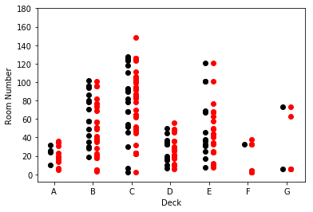

```python
for deckn, deck in enumerate(UniqueDecks):
    deckSurvived = ( cDaF["Deck"] == deck ) & cDaF["Survived"].astype(bool)
    deckDied = ( cDaF["Deck"] == deck ) & ( cDaF["Survived"].astype(bool) == False )
    Survival_by_Deck["Survival Fraction"][deckn] = deckSurvived.sum()/(deckSurvived.sum() + deckDied.sum())
    plt.scatter(( deckn-0.1)*np.ones(deckSurvived.sum()),cDaF["Room"][deckSurvived],c="black")
    plt.scatter((deckn+0.1)*np.ones(deckDied.sum()),cDaF["Room"][deckDied],c="red")

plt.xlabel("Deck")
plt.ylabel("Room Number")
plt.xticks(np.arange(0,7),UniqueDecks)
plt.yticks(np.arange(0,200,20))

print(Survival_by_Deck)
print("")
```

We can see that survival per deck ranged from 10% of the records (Deck F) to 40% (Deck D). Looking at the distribution of room numbers for those that lived (black) vs. those that died (red) doesn't seem to suggest that a particular role for room # in survival. The scarcity of the data makes it difficult to judge whether the observed pattern is meaningful. We could compare the distribution of survival/death to a chi square distribution to determine statistical significance. However, since this information is present in roughly 25% of the data, and assuming the test set is similar in proportion the training set, we are probably better off ignoring it for the moment.

Our last order of business is to assess the difference in explained variance when some of the less significant parameters are removed. This will help protect against overfitting of the training set.

```python
from sklearn.metrics import log_loss
#from scipy.stats import chisqprob

#Thank you, random contributor to stack exchange for this little bit fo code for calculating the p value from the log-likelihood ratio test

def likelihood_ratio(llmin, llmax):
    return(2*(llmax-llmin))
```

```python
lmModelSc.coef_[0]
coefLis = ["%s: %3.2f" % (x, y) for (x, y) in zip(list(Xmx),lmModelSc.coef_[0]) ]
for f in coefLis:
    print(f)
#print([(x,y) for x in list(Xmx), y in lmModelSc.coef_[0]])
#Let's have a look at our weights to see what is more/less important.
```

```
isMale: -2.57
Class1: 1.34
Class2: 0.46
Class3: -0.72
eS: -0.01
eQ: 0.37
eC: 0.41
Age: -0.58
Fare: 0.13
SibSp: -0.31
Parch: -0.08
```

```python
#first, the log likelihood of our current model, which is the negative log loss
LLCurrent = -log_loss(YEval["Survived"],YEval["Prediction"])
print(LLCurrent)
#then, generate a model minus one factor and find the probability that they are different

XmxDrop = Xmx.copy()
XmxDrop.drop(["eS","Parch"],axis=1,inplace=True)

lmModelSc2 = linear_model.LogisticRegression()
lmModelSc2.fit(XmxDrop,Y)
predict2 = lmModelSc2.predict(XmxDrop)
LLPruned = -log_loss(Y,predict2)
print(LLPruned)

lmModelSc3 = linear_model.LogisticRegression()
XmXDrop2 = XmxDrop.drop(["Fare"],axis=1)
lmModelSc3.fit(XmXDrop2,Y)
predict3 = lmModelSc3.predict(XmXDrop2)
LLPruned3 = -log_loss(Y,predict3)
print(LLPruned3)

lmModelSc4 = linear_model.LogisticRegression()
dropSig = XmxDrop.drop(["isMale"],axis=1)
lmModelSc4.fit(dropSig,Y)
predict4 = lmModelSc4.predict(dropSig)
LLPrunedSig = -log_loss(Y,predict4)
print(LLPrunedSig)
```

```
-6.745009948520766
-6.745009948520766
-6.745010845936512
-10.272548273898066
```

```python
a = likelihood_ratio(LLPruned,LLCurrent)
print ( chisqprob(a,3) )

b = likelihood_ratio(LLPrunedSig, LLCurrent)
print(chisqprob(b,4))
```

[output not shown]

```python
lmModelSc2.coef_
```

[output not shown]

```python
lmModelSc3.coef_
```

[output not shown]

```python
XmxDrop.head(2)
```

[output not shown]

```python
from ioFunctions import ReadNProcessCSV
```

```python
Xtest,Ytest= ReadNProcessCSV("test.csv")
```

```python
np.sum(Xtest["Age"].isnull())
Xtest.head(3)
```

|  | isMale | Class1 | Class2 | Class3 | eQ | eC | Age | SibSp |
| --- | --- | --- | --- | --- | --- | --- | --- | --- |
| 0 | True | False | False | True | True | False | 0.392731 | 0 |
| 1 | False | False | False | True | False | False | 1.356873 | 1 |
| 2 | True | False | True | False | True | False | 2.513843 | 0 |

```python
TestPrediction = lmModelSc3.predict(Xtest)
FirstPrediction = lmModelSc3.predict(XmXDrop2)
```

```python
from sklearn.metrics import confusion_matrix
```

```python
TestPrediction
```

```
array([0, 0, 0, 0, 1, 0, 1, 0, 1, 0, 0, 0, 1, 0, 1, 1, 0, 0, 1, 1, 0, 0,
       1, 1, 1, 0, 1, 0, 0, 0, 0, 0, 0, 1, 1, 0, 1, 1, 0, 0, 0, 0, 0, 1,
       1, 0, 0, 0, 1, 0, 0, 0, 1, 1, 0, 0, 0, 0, 0, 1, 0, 0, 0, 1, 1, 1,
       1, 0, 1, 1, 1, 0, 1, 1, 1, 1, 0, 1, 0, 1, 0, 0, 0, 0, 0, 0, 1, 1,
       1, 0, 1, 0, 1, 0, 1, 0, 1, 0, 1, 0, 1, 0, 0, 0, 1, 0, 0, 0, 0, 0,
       0, 1, 1, 1, 1, 0, 0, 1, 1, 1, 1, 0, 1, 0, 0, 1, 0, 1, 0, 0, 0, 0,
       1, 0, 0, 0, 0, 0, 1, 0, 0, 1, 0, 0, 0, 0, 0, 0, 0, 0, 1, 0, 0, 0,
       0, 0, 1, 1, 0, 1, 1, 0, 1, 0, 0, 1, 0, 0, 1, 1, 0, 0, 0, 0, 0, 1,
       1, 0, 1, 1, 0, 0, 1, 0, 1, 0, 1, 0, 0, 0, 0, 0, 0, 0, 0, 0, 1, 1,
       0, 1, 1, 0, 0, 1, 0, 0, 1, 0, 1, 0, 0, 0, 0, 0, 0, 0, 1, 0, 1, 0,
       1, 0, 1, 0, 1, 1, 0, 1, 0, 0, 0, 1, 0, 0, 0, 0, 0, 0, 1, 1, 1, 1,
       0, 0, 0, 0, 1, 0, 1, 1, 1, 0, 1, 0, 0, 0, 0, 0, 1, 0, 0, 0, 1, 1,
       0, 0, 0, 0, 1, 0, 0, 0, 1, 1, 0, 1, 0, 0, 0, 0, 1, 0, 1, 1, 1, 0,
       0, 0, 0, 0, 0, 1, 0, 0, 0, 0, 1, 0, 0, 0, 0, 0, 0, 0, 1, 1, 0, 0,
       0, 0, 0, 0, 0, 1, 1, 1, 0, 0, 0, 0, 0, 0, 0, 0, 1, 0, 1, 0, 0, 0,
       1, 0, 0, 1, 0, 0, 0, 0, 0, 0, 0, 0, 0, 1, 0, 1, 0, 1, 0, 1, 1, 0,
       0, 0, 1, 0, 1, 0, 0, 0, 0, 1, 1, 0, 1, 1, 0, 1, 1, 0, 0, 1, 0, 0,
       1, 1, 0, 0, 0, 0, 0, 0, 1, 1, 0, 1, 0, 0, 0, 0, 1, 1, 0, 0, 0, 1,
       0, 1, 0, 0, 1, 0, 1, 1, 0, 0, 0, 0, 1, 1, 1, 1, 1, 0, 1, 0, 0, 0])
```

```python
confused = confusion_matrix(Y,FirstPrediction)
print(confused)
np.sum(confused)
```

```
[[477  72]
 [102 240]]
```

```
891
```

```python
from ioFunctions import predictionAccuracy
```

```python
predictionAccuracy(Y,FirstPrediction)
```

```
You got an accuracy of 0.8047138047138047 on the  data
```

Let's output our answer by writing a file. Pandas has a write CSV method, but the output format is rather simple so it will be easier to do simple file input/output.

```python
outStream = open("Survival_Prediction.csv",'w')
outStream.write("PassengerId,Survived\n")
for r,p in enumerate(TestPrediction):
    outStream.write(",".join([str(r+892), str(p)])+"\n")

outStream.close()
```